# ps05-rmarkdown

Shisong Gong

2023-02-18

## 1 Load and check data (5pt)

### 1. (1pt) For solving the problems, and answering the questions, create a new rmarkdown document with an appropriate title

### The title of rmardown document is ps05-rmarkdown

### 2. (2pt) Load data. How many rows/columns do we have?

```r
library(tidyverse)
gapMinder <- read_delim("../data/gapminder.csv.bz2")
nrow(gapMinder)
```

```
## [1] 13055
```

```r
ncol(gapMinder)
```

```
## [1] 25
```

### 3. (2pt) Print a small sample of data. Does it look OK?

```r
sample_n(gapMinder, 3)
```

```
## # A tibble: 3 × 25
##   iso3  name  iso2  region sub-r…¹ inter…²  time total…³ ferti…⁴ lifeE…⁵ child…⁶
##   <chr> <chr> <chr> <chr>  <chr>   <chr>   <dbl>   <dbl>   <dbl>   <dbl>   <dbl>
## 1 CAN   Cana… CA    Ameri… Northe… <NA>     2004  3.19e7    1.53    79.9     6.1
## 2 AFG   Afgh… AF    Asia   Southe… <NA>     2012  3.12e7    5.56    62.1    80.3
## 3 ZWE   Zimb… ZW    Africa Sub-Sa… Easter…  2001  1.19e7    3.72    44.0    91.3
## # … with 14 more variables: youthFemaleLiteracy <dbl>, youthMaleLiteracy <dbl>,
## #   adultLiteracy <dbl>, GDP_PC <dbl>, accessElectricity <dbl>,
## #   agriculturalLand <dbl>, agricultureTractors <dbl>, cerealProduction <dbl>,
## #   fertilizerHa <dbl>, co2 <dbl>, greenhouseGases <dbl>, co2_PC <dbl>,
## #   pm2.5_35 <dbl>, battleDeaths <dbl>, and abbreviated variable names
## #   ¹`sub-region`, ²`intermediate-region`, ³totalPopulation, ⁴fertilityRate,
## #   ⁵lifeExpectancy, ⁶childMortality
```

### The data looks fine, but some of data are NA

## 2 Descriptive statistics (15pt)

### 1. (3pt) How many countries are there in the dataset? Analyze all three: iso3, iso2 and name.

```r
numberofiso3 <- length(unique(gapMinder$iso3))
numberofiso3
```

```
## [1] 253
```

```r
numberofiso2 <- length(unique(gapMinder$iso2))
numberofiso2
```

```
## [1] 249
```

```r
numberofname <- length(unique(gapMinder$name))
numberofname
```

```
## [1] 250
```

### Number of iso3 is 253

### Number of iso2 is 249

### Number of name is 250

### 2. If you did this correctly, you saw that there are more names than iso-2 codes, and there are even more iso3 -codes. What is going on? Can you find it out?

#### (a) (5pt) Find how many names are there for each iso-2 code. Are there any iso-2 codes that correspond to more than one name? What are these countries?

```r
gapMinder %>%
  group_by(iso2) %>%
  summarise(num = n_distinct(name)) %>%
  select(iso2, num) %>%
  arrange(desc(num)) %>%
  head(6)
```

```
## # A tibble: 6 × 2
##   iso2    num
##   <chr> <int>
## 1 <NA>      2
## 2 AD        1
## 3 AE        1
## 4 AF        1
## 5 AG        1
## 6 AI        1
```

```r
gapMinder %>%
  filter(is.na(iso2)) %>%
  select(name)
```

```
## # A tibble: 300 × 1
##    name
##    <chr>
##  1 <NA>
##  2 <NA>
##  3 <NA>
##  4 <NA>
##  5 <NA>
##  6 <NA>
##  7 <NA>
##  8 <NA>
##  9 <NA>
## 10 <NA>
## # … with 290 more rows
```

### The NA correspond to more than one name

#### (b) (5pt) Now repeat the same for name and iso3-code. Are there country names that have more than one iso3-code? What are these countries? Hint: two of these entitites are CHANISL and NLD CURACAO.

```r
gapMinder %>%
  group_by(name) %>%
  summarise(num = n_distinct(iso3)) %>%
  select(name, num) %>%
  arrange(desc(num))
```

```
## # A tibble: 250 × 2
##    name                  num
##    <chr>               <int>
##  1 <NA>                    4
##  2 Afghanistan             1
##  3 Albania                 1
##  4 Algeria                 1
##  5 American Samoa          1
##  6 Andorra                 1
##  7 Angola                  1
##  8 Anguilla                1
##  9 Antarctica              1
## 10 Antigua and Barbuda     1
## # … with 240 more rows
```

```r
gapMinder %>%
  filter(is.na(name)) %>%
  distinct(iso3)
```

```
## # A tibble: 4 × 1
##   iso3
##   <chr>
## 1 CHANISL
## 2 GBM
## 3 KOS
## 4 NLD_CURACAO
```

### Four countries: CHANISL, GBM, KOS and NLD_CURACAO

### 3. (2pt) What is the minimum and maximum year in these data?

```r
gapMinder %>%
  filter(!is.na(time)) %>%
  summarise(min = min(time),
            max = max(time))
```

```
## # A tibble: 1 × 2
##     min   max
##   <dbl> <dbl>
## 1  1960  2019
```

## 3 CO2 emissions (30pt)

### Next, let’s analyze CO2 emissions.

### 1. (2pt) How many missing co2 emissions are there for each year? Analyze both missing CO2 and co2_PC. Which years have most missing data?

```r
gapMinder %>%
  group_by(time) %>%
  filter(is.na(co2) | is.na(co2_PC)) %>%
  summarise(num = n()) %>%
  arrange(desc(num)) %>%
  head(6)
```

```
## # A tibble: 6 × 2
##    time   num
##   <dbl> <int>
## 1  2017   217
## 2  2018   217
## 3  2019   217
## 4  1960    60
## 5  1961    60
## 6  1962    58
```

### 2017, 2018 and 2019 have most missing data

### 2. (5pt) Make a plot of total CO2 emissions over time for the U.S, China, and India. Add a few more countries of your choice. Explain what do you see

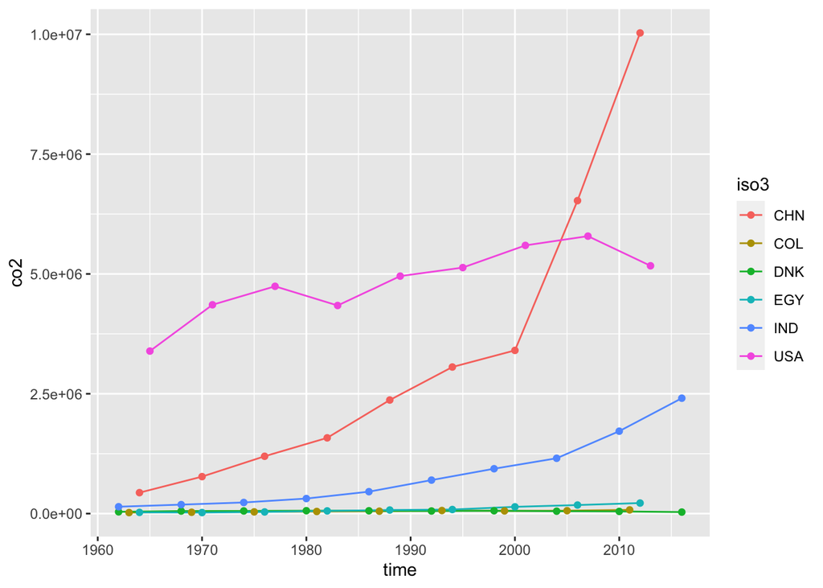

```r
gapMinder %>%
  filter(!is.na(co2)) %>%
  filter(iso3 == c("USA", "IND", "CHN", "DNK", "COL", "EGY")) %>%
  ggplot() +
  geom_line(aes(x = time, y = co2, col = iso3)) +
  geom_point(aes(x = time, y = co2, col = iso3))
```

### The co2 emision of China, India and US are increasing, while the co2 emission of COL, DNK, EGY are stable.

### 3. (5pt) Now let’s analyze the CO2 emissions per capita (co2_PC ). Make a similar plot of the same countries. What does this figure suggest?

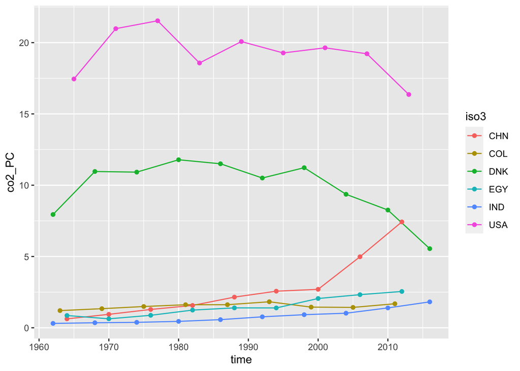

```r
gapMinder %>%
  filter(!is.na(co2)) %>%
  filter(iso3 == c("USA", "IND", "CHN", "DNK", "COL", "EGY")) %>%
  ggplot() +
  geom_line(aes(x = time, y = co2_PC, col = iso3)) +
  geom_point(aes(x = time, y = co2_PC, col = iso3))
```

### The result shows much different than previous one, USA and DNK have higher co2 emission per capita.

### 4. (6pt) Compute average CO2 emissions per capita across the continents (assume region is the same as continent). Comment what do you see.

### Note: just compute averages over countries and ignore the fact that countries are of different size. Hint: Americas 2016 should be 4.80.

```r
gapMinder %>%
  filter(!is.na(co2_PC),
         !is.na(region)) %>%
  group_by(region, time) %>%
  summarise(mean = mean(co2_PC))
```

```
## # A tibble: 285 × 3
## # Groups:   region [5]
##    region  time  mean
##    <chr>  <dbl> <dbl>
##  1 Africa  1960 0.291
##  2 Africa  1961 0.300
##  3 Africa  1962 0.299
##  4 Africa  1963 0.310
##  5 Africa  1964 0.349
##  6 Africa  1965 0.385
##  7 Africa  1966 0.422
##  8 Africa  1967 0.607
##  9 Africa  1968 0.781
## 10 Africa  1969 0.824
## # … with 275 more rows
```

### Europe’s co2 emission per capita is higher than other continents recently

### 5. (7pt) Make a barplot where you show the previous results–average CO2 emissions per capita across continents in 1960 and 2016.

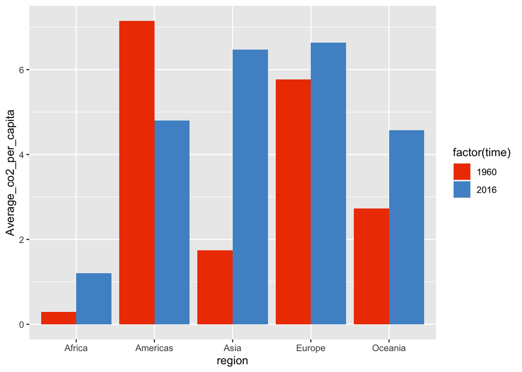

```r
library(ggplot2)
gapMinder %>%
  filter(time == 1960 | time == 2016) %>%
  filter(!is.na(co2_PC),
         !is.na(region)) %>%
  group_by(region, time) %>%
  summarise(Average_co2_per_capita = mean(co2_PC)) %>%
  ggplot(aes(region, Average_co2_per_capita, fill = factor(time))) +
  geom_col(position = "dodge") +
  scale_fill_manual(
    values = c("1960" = "orangered2", "2016" = "steelblue3")
  )
```

### Asia and Europe has higer co2 emission per capita in 2016. Asia increase most rapidly. Americas co2 emission per capita is decreasing.

### 6. Which countries are the three largest, and three smallest CO2 emitters (in terms of CO2 per capita) in 2019 for each continent? (Assume region is continent).

```r
largest_three <- gapMinder %>%
  filter(time == "2019",
         !is.na(region)) %>%
  group_by(region) %>%
  arrange(co2_PC) %>%
  slice_head(n = 3) %>%
  select(region, name) %>%
  print()
```

```
## # A tibble: 15 × 2
## # Groups:   region [5]
##    region   name
##    <chr>    <chr>
##  1 Africa   Angola
##  2 Africa   Burundi
##  3 Africa   Benin
##  4 Americas Aruba
##  5 Americas Argentina
##  6 Americas Antigua and Barbuda
##  7 Asia     Afghanistan
##  8 Asia     United Arab Emirates
##  9 Asia     Armenia
## 10 Europe   Albania
## 11 Europe   Andorra
## 12 Europe   Austria
## 13 Oceania  American Samoa
## 14 Oceania  Australia
## 15 Oceania  Fiji
```

```r
smallest_three <- gapMinder %>%
  filter(time == "2019",
         !is.na(region)) %>%
  group_by(region) %>%
  arrange(co2_PC) %>%
  slice_tail(n = 3) %>%
  select(region, name) %>%
  print()
```

```
## # A tibble: 15 × 2
## # Groups:   region [5]
##    region   name
##    <chr>    <chr>
##  1 Africa   South Africa
##  2 Africa   Zambia
##  3 Africa   Zimbabwe
##  4 Americas Venezuela (Bolivarian Republic of)
##  5 Americas Virgin Islands (British)
##  6 Americas Virgin Islands (U.S.)
##  7 Asia     Uzbekistan
##  8 Asia     Viet Nam
##  9 Asia     Yemen
## 10 Europe   Slovenia
## 11 Europe   Sweden
## 12 Europe   Ukraine
## 13 Oceania  Tuvalu
## 14 Oceania  Vanuatu
## 15 Oceania  Samoa
```

## 4 GDP per capita (50pt)

### Let’s look at GDP per capita (GDP_PC ).

### 1. (8pt) Make a scatterplot of GDP per capita versus life expectancy by country, using data for 1960. Make the point size dependent on the country size, and color those according to the continent. Feel free to adjust the plot in other ways to make it better. Comment what do you see there.

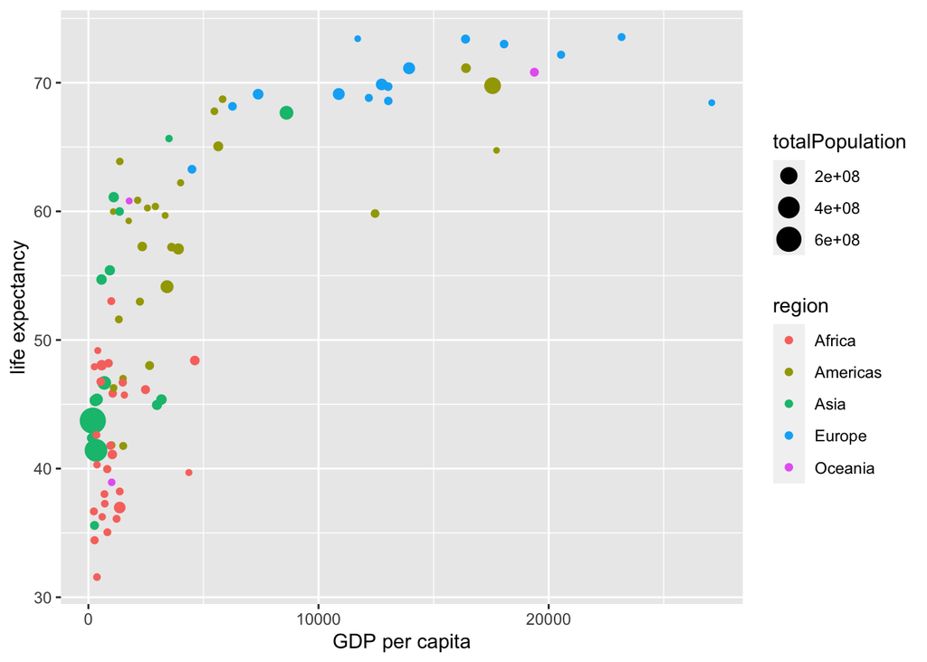

```r
gapMinder %>%
  filter(time == 1960,
         !is.na(region),
         !is.na(GDP_PC),
         !is.na(lifeExpectancy)) %>%
  ggplot(aes(GDP_PC, lifeExpectancy, col = region, size = totalPopulation)) +
  geom_point() +
  labs(x = "GDP per capita",
       y = "life expectancy")
```

### 2. (4pt) Make a similar plot, but this time use 2019 data only.

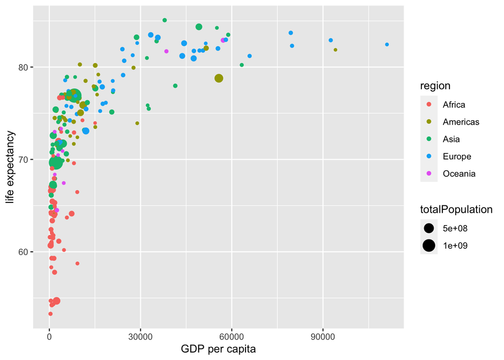

```r
gapMinder %>%
  filter(time == 2019,
         !is.na(region),
         !is.na(GDP_PC),
         !is.na(lifeExpectancy)) %>%
  ggplot(aes(GDP_PC, lifeExpectancy, col = region, size = totalPopulation)) +
  geom_point() +
  labs(x = "GDP per capita",
       y = "life expectancy")
```

### 3. (6pt) Compare these two plots and comment what do you see. How has world developed through the last 60 years?

### The overall GDP per capita and life expectancy is increasing in every continents.

### Europe’s GDP per capita is higher than other continents.

### Two graphs obviously show the huge increase in life expectancy in Asia and Africa.

### 4. (6pt) Compute the average life expectancy for each continent in 1960 and 2019. Do the results fit with what do you see on the figures? Note: here as average I mean just average over countries, ignore the fact that countries are of different size.

```r
gapMinder %>%
  filter(!is.na(lifeExpectancy),
         !is.na(region),
         time == 1960 | time == 2019) %>%
  group_by(region, time) %>%
  summarise(mean = mean(lifeExpectancy))
```

```
## # A tibble: 10 × 3
## # Groups:   region [5]
##    region    time  mean
##    <chr>    <dbl> <dbl>
##  1 Africa    1960  41.5
##  2 Africa    2019  64.1
##  3 Americas  1960  58.6
##  4 Americas  2019  75.8
##  5 Asia      1960  51.6
##  6 Asia      2019  74.6
##  7 Europe    1960  68.3
##  8 Europe    2019  79.4
##  9 Oceania   1960  56.4
## 10 Oceania   2019  73.5
```

### The results fit with what do I see on the figures, since the results clearly

### show the huge incease of life expectancy in Asia and Africa.

### 5. (8pt) Compute the average LE growth from 1960-2019 across the continents. Show the results in the order of growth. Explain what do you see. Hint: these data (data in long form) is not the simplest to compute growth. But you may want to check out the lag() function. And do not forget to group data by continent when using lag(), otherwise your results will be messed up!

```r
gapMinder %>%
  filter(!is.na(lifeExpectancy),
         !is.na(region),
         time == "1960" | time == "2019",) %>%
  group_by(region, time) %>%
  mutate(le_1960 = lag(lifeExpectancy),
         growth = lifeExpectancy - le_1960) %>%
  select(region, le_1960, growth) %>%
  arrange(desc(growth))
```

```
## # A tibble: 384 × 4
## # Groups:   region, time [10]
##     time region   le_1960 growth
##    <dbl> <chr>      <dbl>  <dbl>
##  1  1960 Asia        43.7   25.9
##  2  1960 Americas    41.8   23.0
##  3  2019 Africa      54.3   22.3
##  4  1960 Americas    48.0   20.7
##  5  1960 Asia        43.2   20.1
##  6  1960 Asia        45.6   20.0
##  7  1960 Asia        32.4   19.1
##  8  1960 Africa      31.7   18.7
##  9  1960 Oceania     38.9   17.3
## 10  1960 Asia        45.3   15.8
## # … with 374 more rows
```

### The results show that countries in Asia, Americas and Africa has larger

### increase of life expectancy

### 6. (6pt) Show the histogram of GDP per capita for years of 1960 and 2019. Try to put both histograms on the same graph, see how well you can do it!

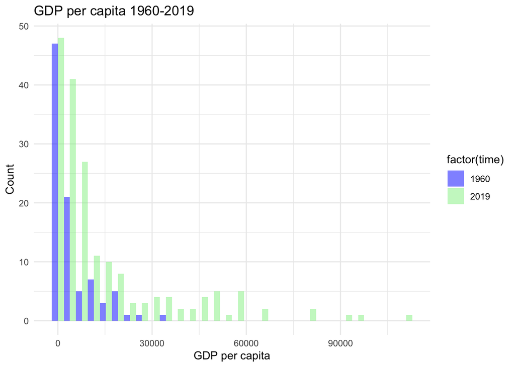

```r
gapMinder %>%
  filter(!is.na(GDP_PC), time %in% c(1960,2019)) %>%
  ggplot(aes(x = GDP_PC, fill = factor(time))) +
  geom_histogram(alpha = 0.5, position = "dodge", bins = 30) +
  scale_fill_manual(values = c("blue", "lightgreen"), labels = c("1960", "2019")) +
  labs(x = "GDP per capita", y = "Count", title = "GDP per capita 1960-2019") +
  theme_minimal()
```

### 7. (6pt) What was the ranking of US in terms of life expectancy in 1960 and in 2019? (When counting from top.)

### Hint: check out the function rank()!

### Hint2: 17 for 1960.

```r
rank_1960 <- gapMinder %>%
  filter(time == "1960",
         !is.na(region),
         !is.na(lifeExpectancy)) %>%
  mutate(rank = rank(desc(lifeExpectancy))) %>%
  filter(name == "United States of America") %>%
  select(rank) %>%
  pull()
rank_1960
```

```
## [1] 17
```

```r
rank_2019 <- gapMinder %>%
  filter(time == "2019",
         !is.na(region),
         !is.na(lifeExpectancy)) %>%
  mutate(rank = rank(desc(lifeExpectancy))) %>%
  filter(name == "United States of America") %>%
  select(rank) %>%
  pull()
rank_2019
```

```
## [1] 46
```

### 8. (6pt) If you did this correctly, then you noticed that US ranking has been falling quite a bit. But we also have more countries in 2019–what about the relative rank divided by the corresponding number of countries that have LE data in the corresponding year?

### Hint: 0.0904 for 1960.

```r
rank_1960_two <- gapMinder %>%
  filter(time == "1960",
         !is.na(region),
         !is.na(lifeExpectancy)) %>%
  mutate(rank = rank(desc(lifeExpectancy)) / n_distinct(name)) %>%
  filter(name == "United States of America") %>%
  select(rank) %>%
  pull()
rank_1960_two
```

```
## [1] 0.09042553
```

```r
rank_2019_two <- gapMinder %>%
  filter(time == "2019",
         !is.na(region),
         !is.na(lifeExpectancy)) %>%
  mutate(rank = rank(desc(lifeExpectancy)) / n_distinct(name)) %>%
  filter(name == "United States of America") %>%
  select(rank) %>%
  pull()
rank_2019_two
```

```
## [1] 0.2346939
```

### Finally tell us how many hours did you spend on this PS

### I spent about 11 hours on this assignment.